# Lecture 21

Scraping Web Tables; Web-scrapping with `selenium`

Byeong-Hak Choe

bchoe@geneseo.edu

SUNY Geneseo

April 18, 2024

## Announcement

### Two Upcoming Teaching Presentations

- April 19, 2024 (Friday):
  - 1:45 P.M. - 2:45 P.M.
  - South Hall 338
- April 22, 2024 (Monday):
  - 2:30 P.M. - 3:30 P.M.
  - South Hall 338
- Please attend these presentations and share your feedback with the job search committee.
- Your participation will be rewarded with bonus credit towards your grade in our DANL course.

## Coding Workflow on Spyder IDE

### Code and comment style

- The `#` mark is Spyder’s comment character.
- Consider using block commenting for separating code sections.
  - `# %%` defines a coding block in Spyder.
- To set your keyboard shortcuts,
  - Preferences > Keyboard Shortcuts > Search “run” and/or “comment”
  - Set the shortcuts for (1) run selection; (2) run cell; (3) toggle comment; (4) blockcomment; and (5) unblockcomment

# Premier on Web-scrapping

## Web Scrapping

### Ethical considerations

> *“If you can see things in your web browser, you can scrape them.”*
- Just because you can scrape them doesn’t mean you should.
  - In US, it is currently legal to scrape data from the web using automated tools, as long as the data are publicly available.
    - hiQ Labs vs. LinkedIn Corp. court ruling.
- It is important to realize that the web scrapping tools are very powerful.
  - It is pretty straightforward to write up a program that can overwhelm a host server.
  - The host server tends to have built-in safeguards that will block you in case of a suspected malicious attack.

## Web Scrapping

### Ethical considerations

- Respect for website owners’ terms of service.
- Respect for copyright and intellectual property.
- Respect for client servers.
- Respect for privacy.

## Web Scrapping

### Clients and servers

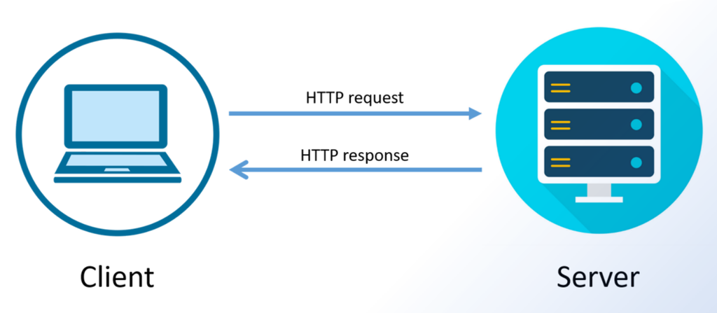

- Computers connected to the web are called **clients** and **servers**.
- **Clients** are the typical web user’s internet-connected devices (e.g., a computer connected to Wi-Fi) and web-accessing software available on those devices (e.g., Firefox, Chrome).
- **Servers** are computers that store webpages, sites, or apps.
- When a client device wants to access a webpage, a copy of the webpage is downloaded from the server onto the client machine to be displayed in the user’s web browser.

## Web Scrapping

### HTTP

- **Hypertext Transfer Protocol (HTTP)** is a language for clients and servers to speak to each other.
- When we type a web address into our browser:
  - The browser finds the address of the server that the website lives on.
  - The browser sends an HTTP request message to the server, asking it to send a copy of the website to the client.
  - If the server approves the client’s request, the server sends the client a `200 OK` message, and then starts displaying the website in the browser.

## Web Scrapping

### URL

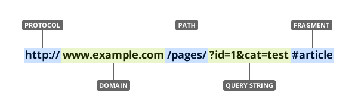

- An uniform resource locator (URL)—commonly know as a “web address”, specifies the location of a resource (such as a web page) on the internet.
- An URL is usually composed of 5 parts
  - The 4th part, the “query string”, contains one or more parameters — in this case, there are two parameters: `id` and `cat`.
  - The 5th part, the “fragment”, is an internal page reference and may not be present.

## Web Scrapping

### HTML

```html
<!DOCTYPE html>
  <html>
    <head>
      <title>Page Title</title>
    </head>
    <body>
      <h1>My First Heading</h1>
      <p>My first paragraph.</p>
    </body>
  </html>
```

- `<!DOCTYPE html>` declaration defines that this document is an HTML document.
- `<html>` element is the root element of an HTML page.
- `<head>` element contains meta information about the HTML page.
- `<title>` element specifies a title for the HTML page.
  - `<title>` is shown in the browser’s title bar or in the page’s tab.
- `<body>` element defines the document’s body, and is a container for all the visible contents, such as headings, paragraphs, images, hyperlinks, tables, lists, etc.
  - `<h1>` element defines a large heading.
  - `<p>` element defines a paragraph.

## Web Scrapping

### HTML body

- tagname
- `<a>`
- `<img>`
- An HTML element is defined by a start tag, some content, and an end tag:

```html
<tagname>Content goes here...</tagname>
```

- The `<a>` tag defines an HTML link.

```html
<a href="https://www.w3schools.com">This is a link</a>
```

- The `<img>` tag defines an HTML image.

```html
<img src="w3schools.jpg" alt="W3Schools.com" width="104" height="142">
```

## Web Scrapping

### HTML table

- `<table>`
- E.g.,
- `<table>` tag defines an HTML table.
  - `<tr>` tag defines each table row.
  - `<th>` tag defines each table header.
  - `<td>` tag defines each data/cell.
- Below is the example HTML table:

```html
<table style="width:100%">
  <tr>
    <th>Firstname</th>
    <th>Lastname</th>
    <th>Age</th>
  </tr>
  <tr>
    <td>Eve</td>
    <td>Jackson</td>
    <td>94</td>
  </tr>
</table>
```

## Web Scrapping

### HTML lists

- Unordered lists
- Ordered lists
- `<ul>` tag defines an unordered lists.
  - `<li>` tag defines each list item.
  - The list items will be marked with bullets (small black circles) by default.

```html
<ul>
  <li>Coffee</li>
  <li>Tea</li>
  <li>Milk</li>
</ul>
```

- `<ol>` tag defines an ordered lists.
  - `<li>` tag defines each list item.
  - The list items will be marked with numbers by default.

```html
<ol>
  <li>Coffee</li>
  <li>Tea</li>
  <li>Milk</li>
</ol>
```

## Web Scrapping

### HTML display values: `<div>`

```html
<div style="background-color:black;color:white;padding:20px;">
  <h2>London</h2>
  <p>London is the capital city of England. It is the most populous city in the United Kingdom, with a metropolitan area of over 13 million inhabitants.</p>
</div>
```

- A *block-level* element always starts on a new line and takes up the full width available.
  - The `<div>` element is a *block-level* and is often used as a container for other HTML elements.
  - The `<div>` element has no required *attributes*, but style, class and id are common.

## Web Scrapping

### HTML display values: `<span>`

```html
<p>My mother has <span style="color:blue;font-weight:bold">blue</span> eyes and my father has <span style="color:darkolivegreen;font-weight:bold">dark green</span> eyes.</p>
```

- An *inline* element does not start on a new line and it only takes up as much width as necessary.
  - The `<span>` element is an *inline* container used to mark up a part of a text, or a part of a document.
  - The `<span>` element has no required *attributes*, but style, class and id are common.

## Web Scrapping

### HTML source code

- HTML elements can be nested (this means that elements can contain other elements).
  - All HTML documents consist of nested HTML elements.
- We can view HTML source for web page.
  - Hit **F12** key (in Chrome or FireFox).
  - Right-click in an HTML page and select `View Page Source` (in Chrome), or similar in other browsers.
  - Right-click on an element (or a blank area), and choose `Inspect` or `Inspect Element` to see what elements are made up of.

## Web Scrapping

### HTML source code: DOM

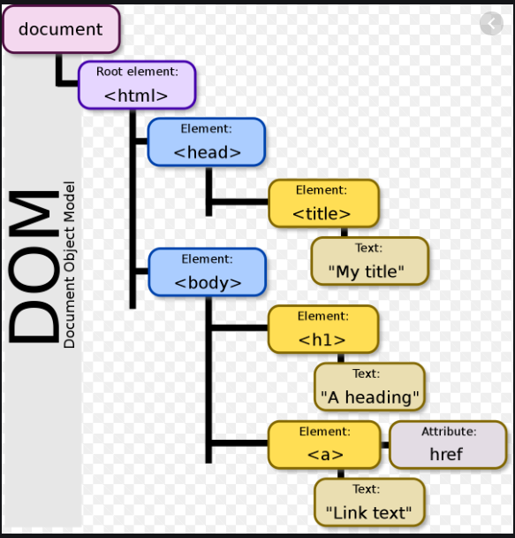

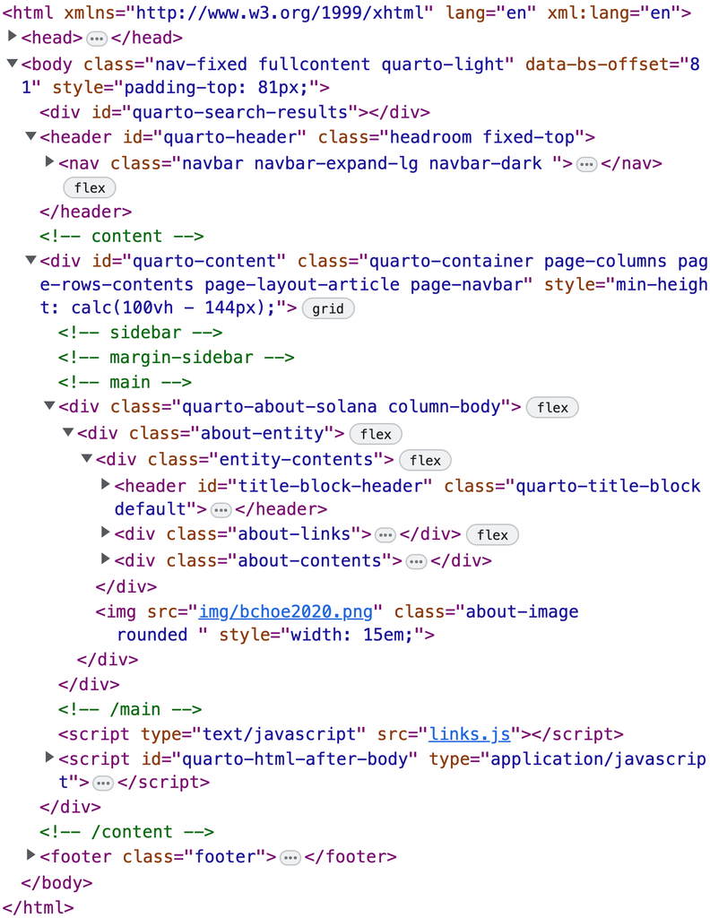

[figure not shown]

## Web Scrapping

### JavaScript (JS) and Cascading Style Sheets (CSS)

- JS
- CSS
- JavaScript (JS) is a client-side programming language.
  - JS helps encourage interactivity on the website.
  - JS runs on the user’s browser instead of on the server as well as often uses 3rd party libraries, so it can increase the functionality of the website.
- Cascading Style Sheets (CSS) is used to format the layout of a webpage (color, font, text size, background, display, etc.).
  - HTML will format the architecture of the house;
  - CSS will be the carpet and walls to decorate the house;
  - JS adds interactive elements in the house, such as opening doors and lighting.